# Reproducible Research: Peer Assessment 1

```r
library(lubridate)
library(dplyr)
library(ggplot2)
library(lattice)
```

## Loading and preprocessing the data.

```r
if(!file.exists("activity.csv")){unzip("activity.zip")}
activity <- read.csv("activity.csv", stringsAsFactors = FALSE)
```

## What is mean total number of steps taken per day?

#### 1. Transform date from character to date format and get total steps per day.

```r
summaryActivity <- activity %>% transform(date = ymd(date)) %>%
    group_by(date) %>% summarise(steps = sum(steps, na.rm = TRUE))
```

#### 2. Make a histogram of the total number of steps taken each day.

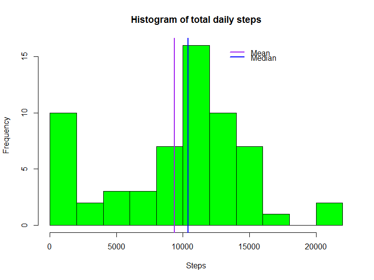

```r
hist(summaryActivity$steps, col = "green",
     main = "Histogram of total daily steps",
     xlab = "Steps", breaks = 10)

abline(v = mean(summaryActivity$steps), lwd = 2, lty = 1, col = "purple")

abline(v = median(summaryActivity$steps), lwd = 2, lty = 1, col = "blue")

legend(x= 13000, y= 16, lwd = 2, lty = 1, col = c("purple","blue"),
       legend = c("Mean", "Median"), bty="n", y.intersp = .5)
```

#### 3. Report the mean and median of the total number of steps taken per day.

##### Mean:

```r
mean(summaryActivity$steps)
```

```
## [1] 9354.23
```

##### Median:

```r
median(summaryActivity$steps)
```

```
## [1] 10395
```

## What is the average daily activity pattern?

#### 1. Transform date from character to date format and get average steps.

```r
summaryInterval <- activity %>% transform(date = ymd(date)) %>%
    group_by(interval) %>% summarise(steps = mean(steps, na.rm = TRUE))
```

#### 2. Make a time series plot.

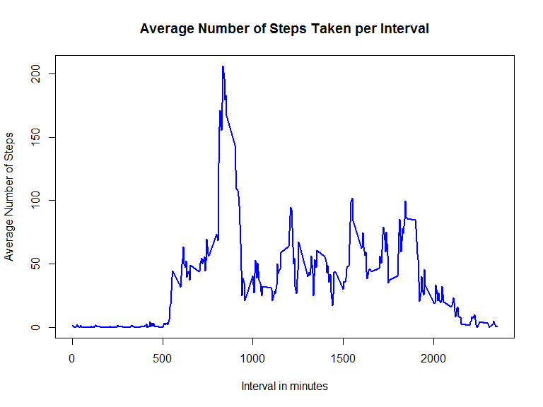

```r
with(summaryInterval, plot(interval, steps, type = "l", col = "blue", lwd = 2,
                           main = "Average Number of Steps Taken per Interval",
                           xlab = "Interval in minutes",
                           ylab = "Average Number of Steps"))
```

#### 3. Which 5-minute interval contains the maximum number of steps?

```r
filter(summaryInterval, steps == max(steps))
```

```
## Source: local data frame [1 x 2]
##
##   interval    steps
##      (int)    (dbl)
## 1      835 206.1698
```

## Imputing missing values.

#### 1. Calculate and report the total number of missing values in the dataset (i.e. the total number of rows with NA s).

```r
table(complete.cases(activity))
```

```
##
## FALSE  TRUE
##  2304 15264
```

##### The FALSE count indicates the total number of missing values.

#### 2. Devise a strategy for filling in all of the missing values in the dataset.

##### Update the missing values with the mean value.

```r
meanStep <- mean(activity$steps,na.rm = TRUE)
```

#### 3. Create a new dataset that is equal to the original dataset but with the missing data filled in.

```r
activityNew <- activity
activityNew$steps[is.na(activityNew$steps)] <- meanStep
```

#### 4. Make a histogram of the total number of steps taken each day and Calculate and report the mean and median total number of steps taken per day.

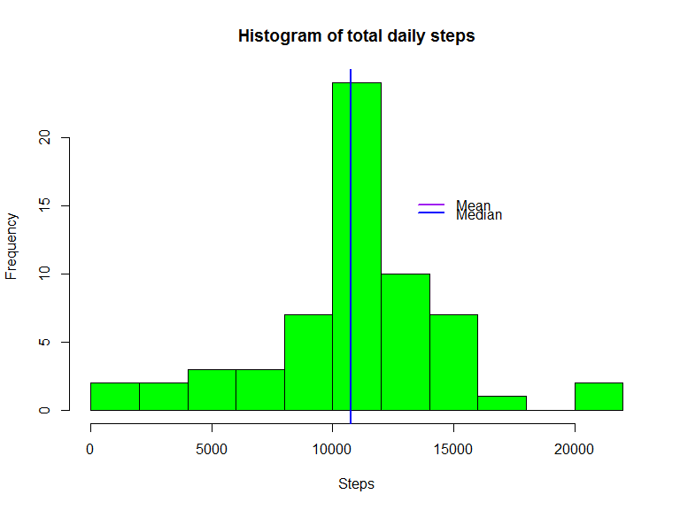

```r
summaryActivityNew <- activityNew %>% transform(date = ymd(date)) %>%
    group_by(date) %>% summarise(steps = sum(steps, na.rm = TRUE))

hist(summaryActivityNew$steps, col = "green",
     main = "Histogram of total daily steps",
     xlab = "Steps", breaks = 10)

abline(v = mean(summaryActivityNew$steps),
       lwd = 2, lty = 1, col = "purple")

abline(v = median(summaryActivityNew$steps),
       lwd = 2, lty = 1, col = "blue")

legend(x= 13000, y= 16, lwd = 2, lty = 1,
       col = c("purple","blue"),
       legend = c("Mean", "Median"), bty="n", y.intersp = .5)
```

##### Mean:

```r
mean(summaryActivityNew$steps)
```

```
## [1] 10766.19
```

##### Median:

```r
median(summaryActivityNew$steps)
```

```
## [1] 10766.19
```

##### There is an increase in Mean and Median and they converge to the same value.

## Are there differences in activity patterns between weekdays and weekends?

#### 1. Create a new factor variable in the dataset with two levels – “weekday” and “weekend”.

```r
activity$day <- ifelse(as.POSIXlt(activity$date)$wday %in%
                           c(0,6), "weekend", "weekday")

activity <- transform(activity,
                      day = factor(day, labels = list("weekday", "weekend")))
```

#### 2. Make a panel plot containing a time series plot.

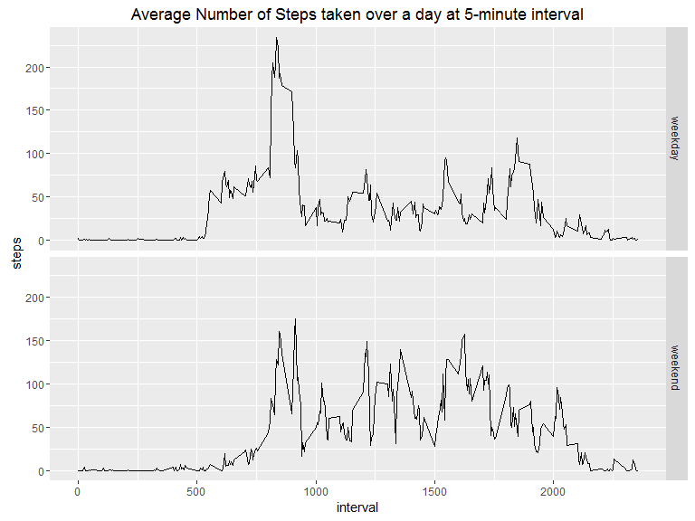

```r
SumActivity <- activity %>% transform(date = ymd(date)) %>%
     group_by(interval, day) %>% summarise(steps = mean(steps, na.rm = TRUE))
qplot(interval, steps, data = SumActivity, geom = "line", facets = day~.,
      main = "Average Number of Steps taken over a day at 5-minute interval")
```